# Reproducible Research: Peer Assessment 1

Gunnar Gunnarsson

## Loading and preprocessing the data

Read in the data. Only preprocessing made is mapping the *date* column to the data type date. We also add the libraries needed for the analysis that follows.

```r
d=read.csv("activity.csv")
d$date=as.Date(d$date)
```

```r
library(dplyr)
```

```r
library(ggplot2)
```

## What is mean total number of steps taken per day?

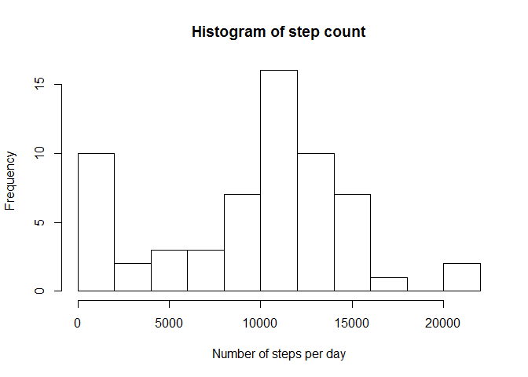

```r
steps_per_day=(d %>% group_by(date) %>%
                  summarise(total_nb_steps=sum(steps,na.rm=T)))
hist(steps_per_day$total_nb_steps, 15,
     xlab="Number of steps per day",
     main="Histogram of step count")
```

```r
mean(steps_per_day$total_nb_steps,na.rm=T)
```

```
## [1] 9354.23
```

```r
median(steps_per_day$total_nb_steps,na.rm=T)
```

```
## [1] 10395
```

## What is the average daily activity pattern?

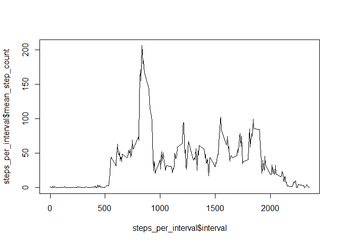

```r
steps_per_interval=(d %>% group_by(interval) %>%
                        summarise(mean_step_count=mean(steps,na.rm=T)))
plot(steps_per_interval$interval,steps_per_interval$mean_step_count,type="l")
```

```r
steps_per_interval$interval[which.max(steps_per_interval$mean_step_count)]
```

```
## [1] 835
```

## Imputing missing values

We calculate the number of missing data points.

```r
sum(is.na(d$steps))
```

```
## [1] 2304
```

We replace the missing values with the average number of steps for the given time interval

```r
d_noNA=d
interval_index=sapply(d$interval,function(i) which(steps_per_interval$interval==i))
d_noNA$steps=ifelse(is.na(d$steps),steps_per_interval$mean_step_count[interval_index],d$steps)
```

We then do the same calculation and graphing as above with no missing values

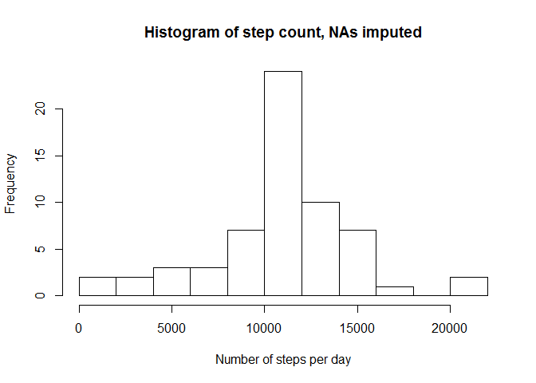

```r
steps_per_day_noNA=(d_noNA %>% group_by(date) %>%
                  summarise(total_nb_steps=sum(steps)))
hist(steps_per_day_noNA$total_nb_steps, 15,
     xlab="Number of steps per day",
     main="Histogram of step count, NAs imputed")
```

```r
mean(steps_per_day_noNA$total_nb_steps)
```

```
## [1] 10766.19
```

```r
median(steps_per_day_noNA$total_nb_steps)
```

```
## [1] 10766.19
```

Imputing the missing values increases the mean number of steps but has little effect on the median value. The imputation of missing values increases the estimate for total daily number of steps.

## Are there differences in activity patterns between weekdays and weekends?

We now examine the difference between weekdays and weekends.

This is run with locale set to Icelandic so the weekend days are *laugardagur* and *sunnudagur* which are the Icelandic terms for *Saturday* and *Sunday* respectively.

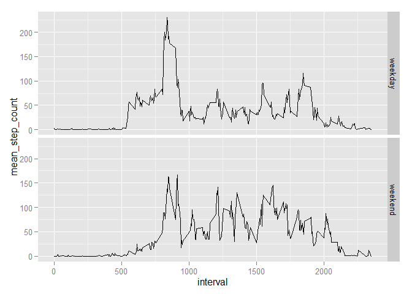

```r
d_noNA$typeofday=as.factor(ifelse(weekdays(d_noNA$date)%in%c("laugardagur","sunnudagur"),"weekend","weekday"))
steps_per_interval_noNA_bytype=(d_noNA %>% group_by(interval,typeofday) %>%
                        summarise(mean_step_count=mean(steps,na.rm=T)))


p=ggplot(steps_per_interval_noNA_bytype,aes(x=interval,y=mean_step_count))+
    geom_line()+facet_grid(typeofday~.)

plot(p)
```